# AI Tournament Project Report

Dane Malenfant

# Motivation

“*Sun Tzu said: Whoever is first in the field and awaits the coming of the enemy, will be fresh for the fight; whoever is second in the field and has to hasten to battle will arrive exhausted.*”[^1].  
Initial decisions taken on a battlefield or gameboard are important since they effect the course and outcome of the engagement. In Pentango Twist, the board is divided into four $3\times3$ quadrants. This baord and its quadrants can be represented by matrices and submatrices. Therefore they also take on properties of matrices. The issue in Pentango Twist is how to deal with the “twist” or specifically the rotations and flips after each player. These moves are essentially some matrix function $f(g(A,C),X): f(A+C,X) \rightarrow D$ that adds a piece and translates a quadrant to the given state. Now, the antagonistic effects of these moves can be nullified if $f(B) = id(B)$ where $X$ is a rotation or flip matrix. For example, let player$_1 = \blacksquare$ and $A =\begin{bmatrix}0 & 0 & 0 \\0 & \blacksquare & 0 \\0 & 0 & 0 \\\end{bmatrix}$. Then $f(A) = id(A) = A$ regardless if $X$ is a rotation or flip.

Instead of trying to win quickly and greedily, wait and build a good environment first. Then you can outlast the opponent over the course of the game and try to win at the end.

# The Algorithm

I wanted an algorithm that switches between planning schemes over the course of the game due to the high branching factor of Pentango Twist and the seemingly valuable central positions of quadrants. Similarily, it is liek STRIPS for the first few turns but ends with a traditional game tree search algorithm to find the goal state. This algorithm is then divided into 3 main phases and the pseudocode is located on the last few pages.

The first phase follows a plan to greedily take the coordinates $(1,1),(1,4),$ if empty for at least two turns. If these coordinates are not empty it will procceed in order to take places from 1 to 12 as in the matrix $\begin{bmatrix}0 & 0 & 0 & 0 & 5 & 0 \\8 & 1 & 12 & 0 & 2 & 0 \\0 & 0 & 0 & 0 & 9 & 0 \\0 & 11 & 0 & 0 & 0 & 0 \\0 & 4 & 0 & 10 & 3 & 6 \\0 & 7 & 0 & 0 & 0 & 0 \end{bmatrix}$. The qudrants and actions are decided at random.

The second phase is the countering phase. After the first two turns, it is possible the opponent is greedily connecting their pieces. After the opponent connects two horizontal or vertical pieces or 3 diagonal pieces, the program will “counter” by blocking the next empty space. The empty space can be between or beside for horizaontal and vetical pieces or just beside for diagonal. If no opponent pieces are connected, the first phase is called again. The qudrants and actions are again decided at random.

The last phase employs $\alpha-\beta$ pruning with negamax[^2] to try to connect sub components created by the previous phases to win the game. Negamax uses that fact that $\max(a,b) = -\min(-a,-b)$ which simplies the amount of lines of minmax alogrithm. It uses a move generating function that takes in the direction and coordination of some piece that is connected to the a central piece taken in phase 1. It then generates the legal moves given the direction of the piece.

For example $\begin{bmatrix}\blacksquare & \square & 0 & 0 & 0 & 0 \\\blacksquare & \square & 0 & 0 & \square & 0 \\0 & 0 & \square & \blacksquare & 0 & 0 \\0 & 0 & 0 & 0 & 0 & 0 \\0 & \square & 0 & 0 & \square & 0 \\0 & 0 & 0 & 0 & 0 & 0 \end{bmatrix}$.

In this matrix, the pieces at (0,1) and (3,3) will generate empty neighbours beside and infront of them given the coordinates of the central piece (1,1) - the coordinates of pieces (0,1) or (3,3). The direction is the sign in front (1,1) - (0,1) = (1,0) means connection is going up while (1,1) - (3,3) = (-2,-2) means the connection is going down right.

If no neighbours can be found all legal moves are used instead. The evaluation function is the sum of of connecting pieces of a player in both the direction of the piece of a move and its reverse direction. If an opponent piece lies in the path the calculation is exited. Since $\alpha-\beta$ pruning wiht negamax has a depth limit. This evlaution function leads to a more desirable value if there is an empty places to connect subcomponents pieces.

# Advantages and Disadvantages

This algorithm overall reduces the branching factor of $\alpha-\beta$ pruning with negamax substantially since the first phases use a specific planning schema instead of trying to predict the best possible state. The first phase is $O(1)$ while the second phase is $O(n)$. So the time limit and memory requirement are not an issue.

Taking the central positions of the quadrants also blocks many possible goals states for the opponent regardless of of rotations or flips. If all central positions are taken then only 16 possible goal states exist. $\begin{bmatrix}\square & \square & \square & \square & \square & \square \\\square & \blacksquare & \square & \square & \blacksquare & \square \\\square & \square & \square & \square & \square & \square \\\square & \square & \square & \square & \square & \square \\\square & \blacksquare & \square & \square & \blacksquare & \square \\\square & \square & \square & \square & \square & \square \end{bmatrix}$.

This can be achieved in 4 turns alone. The first two phases also randomly select a quadrant to flip or rotate. The randomness is forgiving in the start of the game since it is not possible to win until 5 turns. The second phase also makes it almost impossible for the opponent to connect pieces quickly.

The weakenesses include the lack of intelligence in the early phases and a naive evalutaion function. Trading intelligence for efficiency in the early phases means that it is highly unlikely to win early. There is also a failure state that the countering phase can not notice if the opponent can connect two central position from quadrants and another position along that row or column. This is however difficult since rotations and flips are at play. The evaluation function only includes the direction towards the goal state of piece and not that of the opponent. This is bad as including places that can counter the opponent from winning or counter the opponet from winning *and* connecting one’s own pieces are definitley better than just a simple connection.

The classic AI problem of the horizon effect can also appear as not all empty neighbours are generated. Only those in the direction of a piece. This problem also appears in the end of the game as two quadrants might be filled up and just need to be rotated to win the game but the program does not see that and only takes note of the empty place’s chaining factor.

# Discussion and Variants

Originally, I wanted to attempt to remove the dynamic environment of the game completely by comparing the quadrants with matrix transforms of rotations and flips with Strassen’s algorithm[^3] but this would be time consuming and would make seizing cenral positions of quadrants less valuable. Being able to rotate or flip an opponent in the wrong direction is also important.

Next, I was planning on implementing the forward cutting algorithm Prob-Cut[^4] on top of the $\alpha-\beta$ pruning negamax but it seemed to work similarly to my other phased based algorithm. I am not sure if Pentago Twist is that big of a game to require Prob-Cut to work optimally. Since there are only 36 total moves in Pentago Twist.

Lastly, I considered Monte-Carlo Beam Search[^5] in the place of $\alpha-\beta$ pruning negamax but I did not have time to imlement it and compare.

# Improvement

The third phase could greatly be improved with better move ordering function[^6], transposition table[^7] and aspiration windows[^8]. These would enhance the possibility more and better cutoffs for $\alpha-\beta$ pruning negamax and enhance the efficieny of the algorithm. After this, aspiration windows would help to apply $\alpha-\beta$ pruning negamax earlier. I do have aspiration windows in a sense where generating neighbou places does not include all places around a piece but only the ones infront of its direction but a more dynamic approach might have been better.

For the evaluation function, it is definitely posible to create a more dominant one since it only uses my chaining factor. I think it would have been better to transition form the countering phase to the $\alpha-\beta$ phase more smoothly and less discretely. To do this the evaluation function $E$ could have been $E = chainFactor(X) + \frac{isCounterPosition(X)}{TurnNumber}+\dots$ where $isCounterPosition(X)$ is a value that denotes if the move $X$ blocks the opponent from connecting pieces and $TurnNumber$ is the number of the turn. This would transition form countering to focusing on winning and connecting pieces on the board since the $TurnNumber$ increases throughout the game.

Finally, employing a meta-heuristic to transition across all phases of the algorithm could lead to better decisions. Prepocessing the board and weighting the centres of the quadrants higher at the start would lead the $\alpha-\beta$ to select the first. This would be followed by countering and winning phases in a way that is similar to simmulated annealing as in the program converges on trying to win after it builds a good board environment.

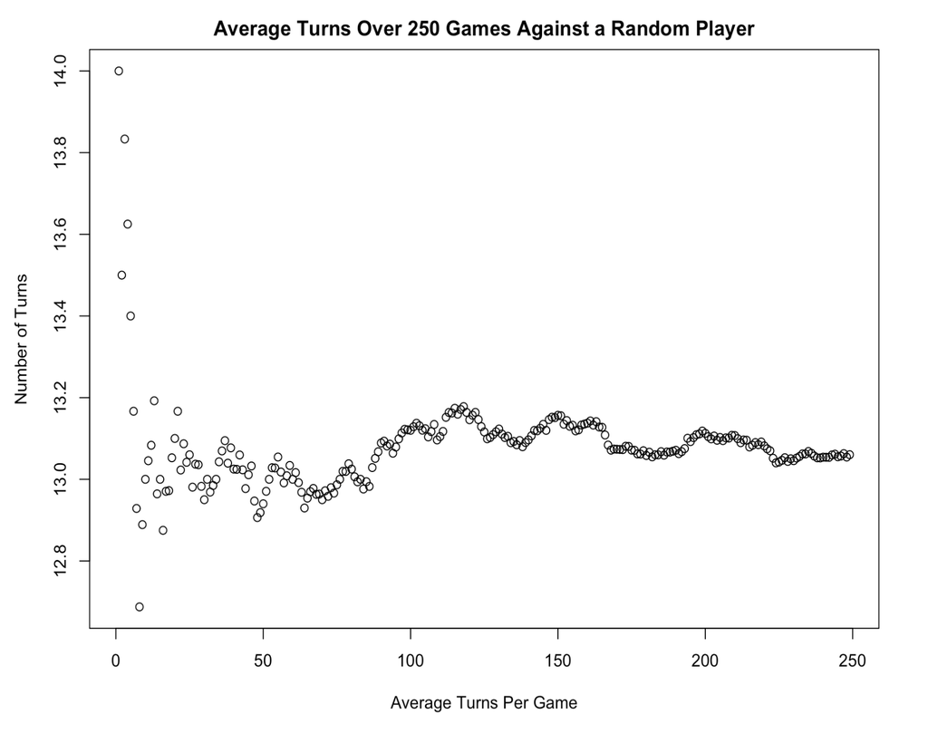

Average Turns Over 250 Games Against Random Player.

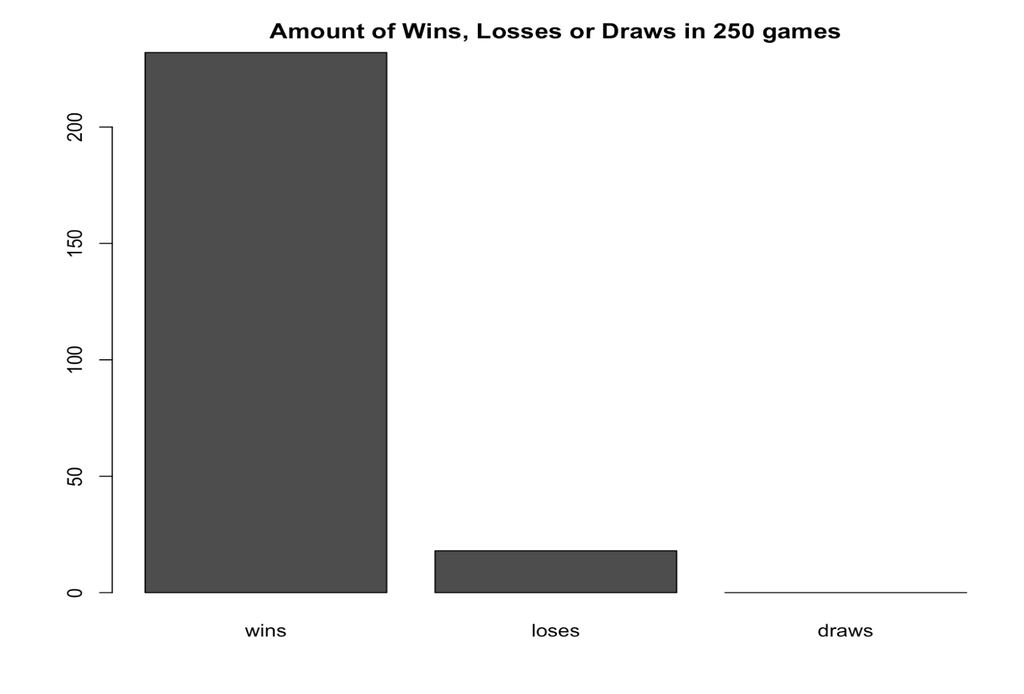

Amount of Games Won, Lost, Drawn Against Random Player

# PseudoCode

**Student Player**

```
________________________
StudentPlayer(BoardState):
________________________

  if getTurnNumber(BoardState) < 2:
    return Move(getTurnNumber(BoardState))

  else if getTurnNumber(BoardState) < 6:
    return Move secondPhase(Boardstate)

  else:
    MoveList
    for Moves from (linearDFS(Central Quadrant Pieces)):

      Movelist.add(thirdPhase(2, -Infinity, Infinity, BoardState, BoardStateClone, Moves.getCoord,
      Moves.getCoord null))

    return Best(MoveList)

_____________________________________________________
```

**Phase 1**

```
________________________
firstPhase(turn number):
________________________
  Cases by turn number:

    Case turn 1:
      ifLegal(return move(1,1))
      else
        firstPhase(turn number + 1)
      endif

    Case turn 2:
      ifLegal(return move(1,4))
      else
        firstPhase(turn number + 1)
      endif
    .
    .
    .
    endCases
_____________________________________________________
```

**Phase 2**

```
________________________
secondPhase(Boardstate):
________________________

  for places in [(0,4):(4:0)]:
   return block(connecting opponent pieces)

  for places in [(1,5):(1:5)]:
   return block(connecting opponent pieces)

  for places in [(0,1):(4:5)]:
   return block(connecting opponent pieces)

  for places in [(1,0):(5:4)]:
   return block(connecting opponent pieces)

  for each quandrant in Boardstate:
    for each row in quadrant perimeter:
      return block(horizontal opponent pieces)
    for each column in quadrant perimeter:
       return block(vertical opponent pieces)

  return firstPhase(1)
_____________________________________________
```

**Phase 3**

```
___________________________________________________________________________________________
thirdPhase(depth, alpha, beta, BoardState, BoardStateClone, currCoord, prevCoord, BestMove)
___________________________________________________________________________________________

  if depth = 0:
    return eval(BestMove, BoardStateClone, currCoord, prevCoord)

  childNodes = generateMoves(BoardStateClone, currCoord, prevCoord)

  if size(childNodes) = 0:
              childNodes = getAllLegalMoves()

              if size(childNodes) = 0:
                 return BestMove
  value = -Infinity;

  currentBest = childNodes[0];

  for child in childNodes:
    value = max(value, -(getValue(ThirdPhase(depth - 1, -beta, -aalpha, BoardStateClone, BoardState, child,
    currCoord, child)))

    if alpha < value:
      alpha = value
      currentBest = child

    BoardStateClone = BoardState

    if alpha >= beta:
      break;

  return currentBest
_____________________________________________________
```

**Move Generation**

```
_____________________________________________________
generateMoves(BoardStateClone, currCoord, prevCoord):
_____________________________________________________
  xDirection = getX(prevCoord) - getX(currCoord)
  yDirection = getX(prevCoord) - getX(currCoord)
  MoveList

  if (xDirection, yDirection) = up:
    MoveList.add(getMovePlacement(Above, currCoord))
    MoveList.add(getMovePlacement(Right, currCoord))
    MoveList.add(getMovePlacement(Left, currCoord))
    MoveList.add(getMovePlacement(UpLeft, currCoord))
    MoveList.add(getMovePlacement(UpRight, currCoord))

  else if (xDirection, yDirection) = upRight:
    MoveList.add(getMovePlacement(UpRight, currCoord))
    MoveList.add(getMovePlacement(Right, currCoord))
    MoveList.add(getMovePlacement(Above, currCoord))

  else if ...
  .
  .
  .

  return MoveList
_____________________________________________________
```

**Evaluation**

```
_____________________________________________________
eval(currentMove, BoardStateClone,  prevCoord):
_____________________________________________________
  chainFactor = 0

  if quadrant = 1:

    if flip:
      chainFatcor = chain(prevCoord, BoardStateClone, getY(currentMove), getX(currentMove) )
    else:
     (rX, rY) = rotate(getX(currentMove), getY(currentMove))
     chainFatcor = chain(prevCoord, BoardStateClone, rX, rY )
  .
  .
  .
  end if

  value(currentMove) = chainfactor

  return currentMove
_____________________________________________________
```

**Heuristic Function**

```
_____________________________________________________
chain(prevCoord, BoardStateClone, X, Y) :
_____________________________________________________


  xDirection  = getX(prevCoord) - X
  yDirection = getY(prevCoord) - Y
  chainfactor = 0

  for places in (xDirection, yDirection) along the path of (X,Y) in Boardstate:
    if isMine(place):
      chainfactor = chainfactor + 1
    else if isOpponent(place):
      break;

  for places in (-xDirection, -yDirection) along the path of (X,Y) in Boardstate:
    if isMine(place):
      chainfactor = chainfactor + 1
    else if isOpponent(place):
      break;


return chainfactor
_____________________________________________________
```

[^1]: Sun Tzu, The Art of War. Translated by Gilles; page 39; https://www.utoledo.edu/rotc/pdfs/the_art_of_war.pdf
[^2]: https://en.wikipedia.org/wiki/Negamax#Negamax_with_alpha_beta_pruning
[^3]: https://en.wikipedia.org/wiki/Strassen_algorithm#Algorithm
[^4]: https://www.chessprogramming.org/ProbCut
[^5]: https://www.researchgate.net/publication/254057146_Monte_Carlo_Beam_Search
[^6]: https://www.chessprogramming.org/Move_Ordering
[^7]: https://en.wikipedia.org/wiki/Negamax#Negamax_with_alpha_beta_pruning_and_transposition_tables
[^8]: https://www.chessprogramming.org/Aspiration_Windows